# Activity Monitoring Project

Lynn Kiaer

Sunday, October 19, 2014

## Loading the Data

```r
setwd(".")
data <- read.csv("./data/activity.csv")
```

## Total Steps Per Day

First, calculate the total number of steps for each day, and then create a histogram of the daily totals.

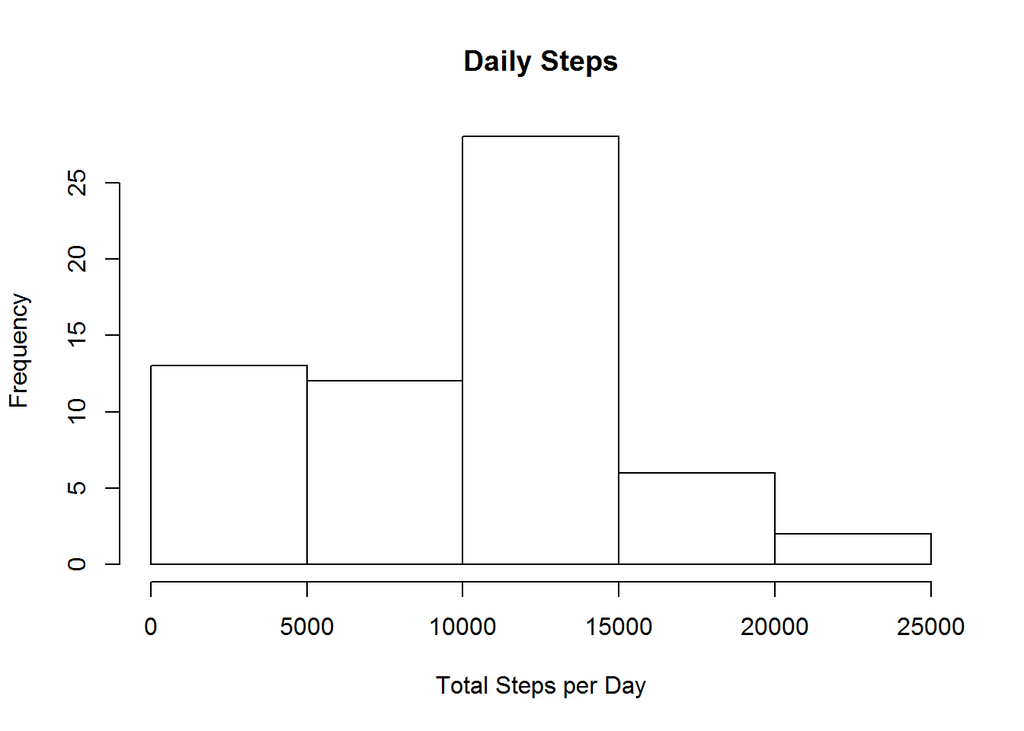

```r
daily <- aggregate(data$steps, list(data$date), sum, na.rm = TRUE, simplify = TRUE)
hist(daily[, 2], main = "Daily Steps", xlab = "Total Steps per Day")
```

Based on the plot, the mean and median should be around ten thousand steps per day.

```r
mean(daily[, 2])
```

```
## [1] 9354
```

```r
median(daily[, 2])
```

```
## [1] 10395
```

The mean (9354) is a bit lower than the median (10395), not surprising since the mean is more affected by extreme values than the median.

## Daily Activity Pattern

To determine the daily activity pattern, we need to average the readings for each interval and plot the resulting time series.

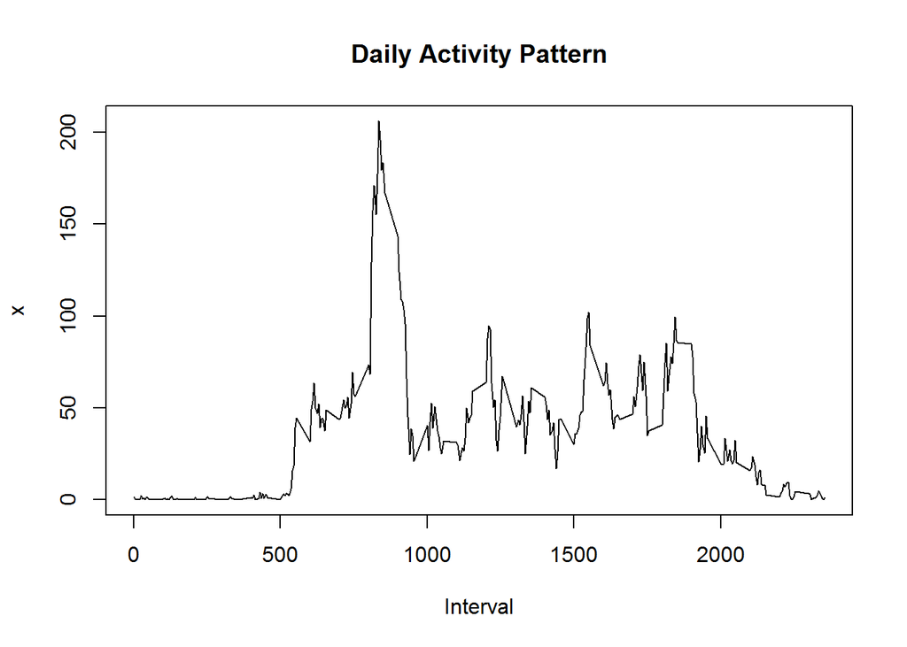

```r
pattern <- aggregate(data$steps, list(data$interval), mean, na.rm = TRUE, simplify = TRUE)
plot(pattern, type = "l", main = "Daily Activity Pattern", xlab = "Interval")
```

```r
pattern[max(pattern$x),]
```

```
##     Group.1    x
## 206    1705 56.3
```

## Imputing Missing Data

Imputing missing data is always a bit of a challenge. If we use the average for the balance of the day, and the missing data includes a lot of time sleeping, or the most active part of the day, we could end up with very unreasonable numbers. Using the average for the time period is probably a bit better, though it may tend to blur any distinction between weekdays and weekends.

```r
missing <- sum(is.na(data$steps))
missing
```

```
## [1] 2304
```

```r
missing / nrow(data)
```

```
## [1] 0.1311
```

So about 13% of the data is missing. Not great, but not awful either. Now, to create a dataset that has the same values as the original, where they exist, and replaces the missing values with imputed ones. We’ll be a little clever and calculate the standard deviation of the interval means, and use that to generate a little variability into the imputed data. There is doubtless a snazzy way to do this, but I’ll do it with a loop…

```r
seed <- 1
i <- 1
imputed <- data
dev <- aggregate(data$steps, list(data$interval), sd, na.rm = TRUE, simplify = TRUE)
while(i <= nrow(imputed)) {
        if (is.na(imputed$steps[i])) {
                m <- pattern[which(pattern$Group.1 == imputed$interval[i]), 2]
                s <- dev[which(dev$Group.1 == imputed$interval[i]), 2]
                imputed$steps[i] <- trunc(rnorm(1,m, s))
        }
        i <- i + 1
}
sum(is.na(imputed$steps))
```

```
## [1] 0
```

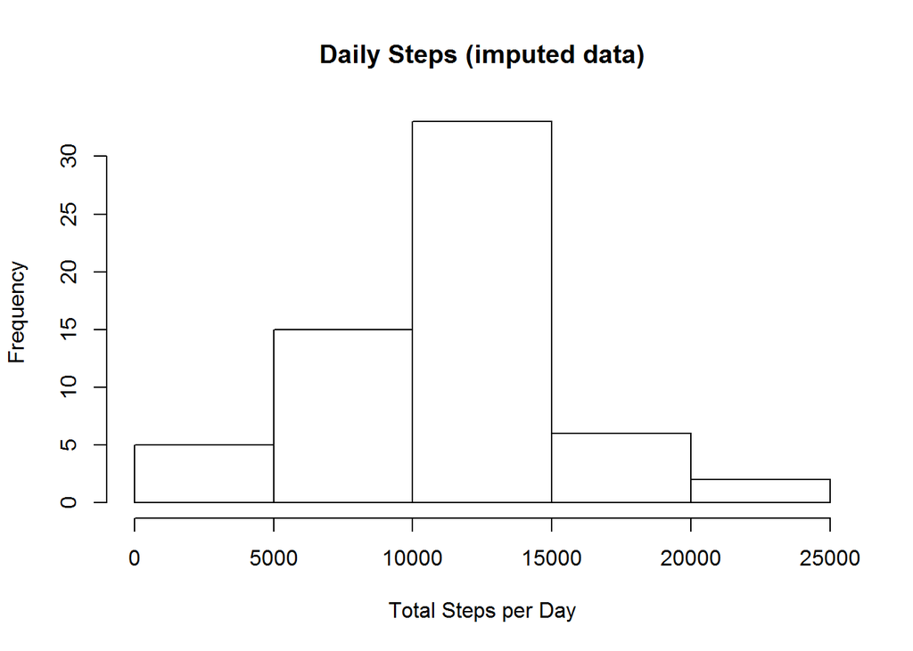

```r
impdaily <- aggregate(imputed$steps, list(imputed$date), sum, na.rm = TRUE, simplify = TRUE)
hist(impdaily[, 2], main = "Daily Steps (imputed data)", xlab = "Total Steps per Day")
```

```r
mean(impdaily[, 2])
```

```
## [1] 10713
```

```r
median(impdaily[, 2])
```

```
## [1] 10600
```

The effect of imputing the missing data is to increase both the mean (a lot) and the median (by a bit less), bringing them much closer together. The histogram show fewer days with very small numbers of steps, and more with a moderate number. The days with a lot of steps apparently didn’t have much missing data (which makes sense).

I think I am out of time.